# Lab8_SNC

## Exercise 4

Upload and visualize the tree file from the FastTreeMP output creating on CIPRES. Use treeio to read the data and ggtree to visualize the tree. Color the tree according to the domains of life.

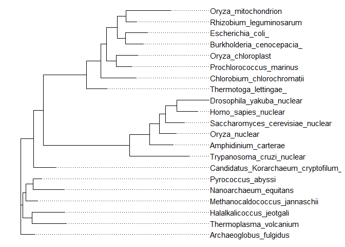

```r
TOL_tree <- read.tree('data/TOL_fastree_result.tre')
# Determine the nodes for the domains based on the species in the tree
tree_plot <- ggtree(TOL_tree) +
  geom_tiplab(align = TRUE, linesize = 0.5) +
  xlim(0, 1.75)
tree_plot
```

```r
# For eukaryotes, Drosophilia and Trypanosoma share the base common root
# For bacteria, Thermotoga and E. coli share a common base root
# For Archaea, Candidatus korarchaeum and Archaeoglobus share a common base root
# These will be used to determine the nodes for each domain
```

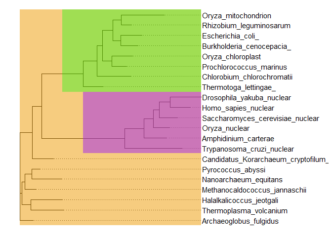

```r
# First, determine the MRCA for all domains
mrca_euk = MRCA(TOL_tree, 'Drosophila_yakuba_nuclear', 'Trypanosoma_cruzi_nuclear')
mrca_bac = MRCA(TOL_tree, 'Thermotoga_lettingae_', 'Escherichia_coli_')
mrca_arch = MRCA(TOL_tree, 'Candidatus_Korarchaeum_cryptofilum_', 'Archaeoglobus_fulgidus')
# Now, add the highlights for each domain of life
colored_tree <- tree_plot +
  geom_highlight(mrca_arch, fill = 'orange2') + # Archaea
  geom_highlight(mrca_euk, fill = 'purple') + # Eukarya
  geom_highlight(mrca_bac, fill = 'green', alpha = 0.35, extend = 0.22) # Bacteria
colored_tree
```

Note how the extend argument of the highlight geom for bacteria was used to extend the highlight to cover the dotted line of the tree (to cover the orange highlight over the entire tree due to the Archaea highlight). Additionally, the bootstrap values for all nodes could be displayed using the nodelab() geom (geom_nodelab()).

For fun, here is the same highlighted tree (this time a cladogram to clearly show the branches) in circular form -

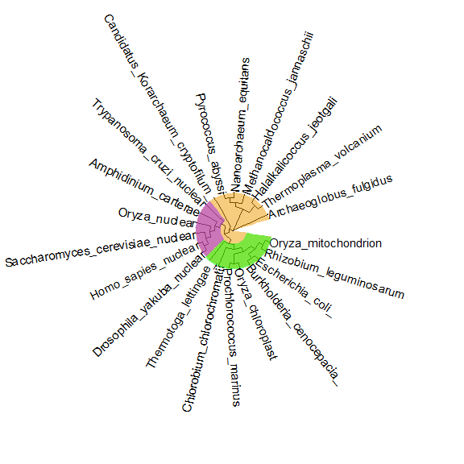

```r
circle_TOL_tree <- ggtree(TOL_tree, branch.length = 'none', layout = 'circular') +
  geom_tiplab(align = TRUE) +
  xlim(0,38) +
  geom_highlight(mrca_arch, fill = 'orange2') + # Archaea
  geom_highlight(mrca_euk, fill = 'purple') + # Eukarya
  geom_highlight(mrca_bac, fill = 'green', extend = 0.22) # Bacteria
circle_TOL_tree
```

# References

Liang, Huyi, Tommy Tsan-Yuk Lam, Xiaohui Fan, Xinchun Chen, Yu Zeng, Ji Zhou, Lian Duan, et al. 2014. “Expansion of Genotypic Diversity and Establishment of 2009 H1n1 Pandemic-Origin Internal Genes in Pigs in China.” *Journal of Virology* 88 (18). https://doi.org/10.1128/JVI.01327-14.

Turner, Stephen. 2017. “Visualizing and Annotating Phylogenetic Trees with R+ggtree.” Tutorial. 2017. https://4va.github.io/biodatasci/r-ggtree.html.